# Assignment 3

Paolo Mariani 800307

# 1) Il problema e la funzione da minimizzare

Il problema considerato riguarda il posizionamento di una struttura di approvvigionamento in un punto $f(\chi , \nu)$ situato all’interno di una mappa (con $\chi , \nu$ incognite relative alla posizione della struttura), in maniera tale per cui tutti la somma di tutte le distanze dei clienti che intendono approvvigionarsi da essa (note all’interno del dataset e indicate con $p_i = (x_i,y_i)$) sia minore possibile.  
I clienti vengono rappresentati nello spazio bidimensionale attraverso il seguente grafico:

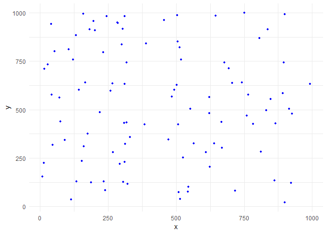

Fornite le coordinate del cliente i-esimo, la distanza tra la struttura ed il cliente viene così calcolata:

$d(f,p_i) = log((\chi - x_i)^2+1)+log((\nu - y_i)^2+1)$

La funzione da minimizzare restituisce la posizione $f(\chi, \nu)$ calcolata come:

$f(\chi,\nu) = \sum^{n}_{i=1} d(f,p_i)$

Si assume che i costi da sostenere per la costruzione della struttura siano fissi (non dipendenti dalla posizione considerata) e che le coordinate $\chi,\nu$ della struttura non siano scelte all’interno di una serie di punti noti a nostra disposizione (ma siano calcolati dall’algoritmo).

## Funzione di distanza

L’implementazione della funzione della distanza in codice R è la seguente:

```r
fun = function(chi, nu, df){
  res = 0
  for (i in c(1:nrow(df))) {
    res = (log((chi - df$x[i])^2 + 1)) + (log((nu - df$y[i])^2 + 1)) + res
  }
  return(res)
}
```

# 2) Gradiente della funzione di distanza

Il gradiente della funzione da minimizzare è definito dalla seguente formula matematica:

$$\nabla f(n_k) =
\begin{cases}
\frac{2(\chi - x_i)}{((\chi - x_i)^2+1)}\\
\frac{2((\nu - y_i))}{((\nu - y_i)^2+1)}
\end{cases}$$

L’equivalente della funzione in codice R è definito dal seguente script:

```r
gradient = function(chi, nu, df){
  res1 = 0
  res2 = 0
  for(i in c(1:nrow(df))){
    res1 = (2*(chi-df$x[i]))/((chi-df$x[i])^2 + 1) + res1
    res2 = (2*(nu-df$y[i]))/((nu-df$y[i])^2 + 1) + res2
  }
  return(c(res1, res2))
}
```

# 3) Implementazione dell’algoritmo Steepest Descent Method e risoluzione del problema con esso

Il metodo scelto per l’ottimizzazione della funzione è il metodo del gradiente (*Steepest Descent Method*), ossia un metodo che permette di ottimizzare rapidamente una funzione tramite un semplice algoritmo; questo algoritmo è in grado di restituire un punto che rappresenta un ottimo locale (di cui però non si conosce l’ottimalità globale), cioè un punto in cui la funzione assume un valore ottimo (minimo o massimo) in un intorno considerato.  
Il metodo del gradiente possiede le seguenti componenti fondamentali:

- un punto di partenza $x_k$
- un passo $\alpha_k$ che stabilisce di quanto la funzione si sposta all’interno della mappa ad ogni iterazione
- una direzione $d_k$ lungo la quale muoversi, massimizzando con il segno + e minimizzando con il segno -
- una funzione da ottimizzare $f$
- il gradiente della funzione $\nabla f$

Prevede l’esecuzione dei seguenti passi:

1. Si sceglie un punto iniziale $x_k$ fornito all’algoritmo o scelto casualmente
2. Si calcola il gradiente della funzione $\nabla f(x_k)$:
3. Si associa alla direzione $d_k$ il gradiente della funzione con il segno + o - a seconda del tipo di ottimizzazione prestabilita: $d_k =\pm\nabla f(x_k)$
4. Si calcola il punto successivo della funzione (fornita una dimensione del passo $\alpha_k$) :  
   $x_{k+1} = x_k + \alpha_k*d_k$
5. Si effettua lo stop dell’algoritmo sotto tre condizioni:
   - Il gradiente nel punto $x_{k+1}$ è nullo
   - Viene raggiunto un valore di precisione inferiore ad una soglia predeterminata $e$, valutato con $| f(x_{k+1})- f(x_k)| < e$ o in alternativa $||\nabla f(x_{k+1})|| < e$
   - Si raggiunge un numero massimo di iterazioni prestabilite

**NB** *Fornito un punto ($\chi, \nu$) generico in input all’algoritmo che si occuperà della ottimizzazione si otterrà in output una coppia di coordinate ($\chi_{opt}, \nu_{opt}$) che rappresenterà l’ottimo locale in cui la funzione è minimizzata*

## Algoritmo Steepest Descent Method

Il procedimento che è stato descritto nel paragrafo precedente si traduce in codice R con il seguente script:

```r
gradientDescent = function(df, v.init, grad, passo, iters){
  par = loss = matrix(NA, nrow = iters + 1, ncol = 2)
  par[1,] = v.init
  for(k in 1:iters){
    loss[k,] = grad(par[k,1], par[k,2], df)
    par[k+1,] = par[k,] - passo * loss[k,]
  }
  return(list(par = par))
}
```

Restituirà una lista contenente le soluzioni, di cui l’ultimo elemento rappresenta l’ottimo, il punto in cui l’algoritmo converge e termina l’esecuzione.  
**NB** Si sceglie di mantenere il valore del passo pari a 0.01 per tutte le sue esecuzioni.

## Risoluzione del problema

Si procede con la risoluzione del problema selezionando il punto all’interno della mappa, da questo punto si procederà a svolgere l’ottimizzazione della funzione:

```r
x = 340
y = 380
start = c(x,y)
opt = data.frame(gradientDescent(df, start,  gradient, 0.01, 1000))
```

```r
result = c(opt$par.1[1001], opt$par.2[1001])
fresult = fun(result[1],result[2],df)
```

Si osserva che l’algoritmo, partendo dal punto iniziale $p_1 = ($ 340, 380 $)$, restituisce l’ottimo $p_{opt}= ($ 327.783271, 376.006984 $)$; il risultato nella maggior parte dei casi non è molto lontano dal punto iniziale: probabilmente si deve ciò al fatto che la funzione possieda molteplici punti di ottimo locale dai quali l’algoritmo (in maniera del tutto corretta) non si allontana una volta che vengono raggiunti, inoltre la combinazione di parametri “passo” e “numero di iterazioni” influisce notevolmente sul percorso che l’algoritmo segue (dimensioni ridotte di passo e del numero di iterazioni non permettono di percorrere molta strada all’interno della mappa).  
Si procede con l’osservazione del punto restituito dall’algoritmo nella mappa:

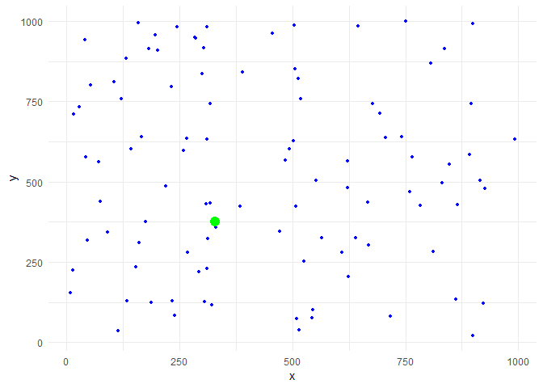

```r
plot = ggplot(df, aes(x = x, y = y)) +
  geom_point(size = 1, col= "blue") +
  geom_point(mapping = aes(x = result[1], y = result[2]), col = "green", size = 4) +
  theme_minimal()
plot
```

Si può osservare, eseguendo il codice con parametri di inizio diversi, come il punto finale cambi spesso posizione e sia influenzato fortemente dal punto iniziale; Si procede quindi a creare una versione più affidabile dell’algoritmo, così che sia più efficace nel predire la posizione corretta e non influenzato dall’andamento altalenante della funzione.

## Ottimizzazione del metodo di ricerca

Si decide di aumentare la probabilità di trovare il punto ottimo globale applicando il seguente algoritmo:

1. Si divide la mappa lungo la quale sono distribuiti i clienti in 25 zone diverse, secondo un reticolo 5x5
2. Si seleziona il punto centrale di ciascun reticolo e lo si inserisce in una lista di punti noti
3. Si inizializza l’algoritmo Steepest Descent Method con i punti appena stabiliti, l’esecuzione avverrà 25 volte con un punto diverso ad ogni iterazione
4. I risultati delle 25 iterazioni vengono salvati in un dataframe “results” dove sarà possibile osservare e confrontare i valori della funzione in ciascun punto

Il ragionamento che sta alla base del procedimento appena descritto è il seguente: applicando il metodo Steepest Descent si procede ad ottimizzare una funzione partendo da un punto che risulta estremamente influente sul risultato, specialmente se la funzione possiede una numerosità molto elevata di minimi locali; per poter risolvere questo bias si stabilisce di confrontare 25 punti equalmente distribuiti lungo la mappa (ciascuno al centro di una zona al quale appartiene) aumentando la probabilità di trovare l’ottimo globale o perlomeno un valore vicino ad esso, effettuando un semplice confronto sui valori della funzione ottenuti.  
L’implementazione dell’algoritmo tramite codice R è la seguente:

```r
max_x = max(df$x)
min_x = min(df$x)
max_y = max(df$y)
min_y = min(df$y)

range_x = (max_x - min_x)/5
range_y = (max_y - min_y)/5
semirange_x = range_x/2
semirange_y = range_y/2
#lista di coordinate note
coord = list(c(98.3,97.7),c(294.9,97.7),c(491.5,97.7),c(688.1,97.7),c(884.7,97.7),c(98.3,293.1), c(98.3, 488.5),c(98.3, 683.9),c(98.3, 879.4),c(294.9,293.1),c(294.9,488.5),c(294.9,683.9),c(294.9,879.3),c(491.5,293.1),c(491.5, 488.5),c(491.5, 683.9),c(491.5, 879.3),c(688.1,293.1), c(688.1,488.5), c(688.1,683.9), c(688.1,879.3), c(884.7, 293.1), c(884.7, 488.5), c(884.7, 683.9), c(884.7, 897.3))

results = data.frame(matrix(NA, ncol=2, nrow=25))
for(i in 1:25){
  temp = as.data.frame(gradientDescent(df, coord[[i]], gradient, 0.01, iters = 1000))
  results[i,1] = temp$par.1[1001]
  results[i,2] = temp$par.2[1001]
}
colnames(results) = c("X","Y")

for (i in 1:25){
  results$FO[i] = fun(results$X[i], results$Y[i], df)
}
min_fo = min(results$FO)
minpt = c(results$X[which(results$FO == min_fo)],results$Y[which(results$FO == min_fo)])
```

Il valore della funzione associato al punto minimo $p_{opt} = ($ 305.6927048, 485.7431485 $)$ risulta essere 2022.0571777, tra tutti i punti considerati si trova in una regione centrale che rispecchia in maniera più veritiera il luogo reale nel quale la struttura dovrebbe essere posizionata. Si ricorda che il risultato ottenuto non è l’ottimo globale: è il valore che con una probabilità più alta si avvicina ad esso ma rimane ottimo locale.

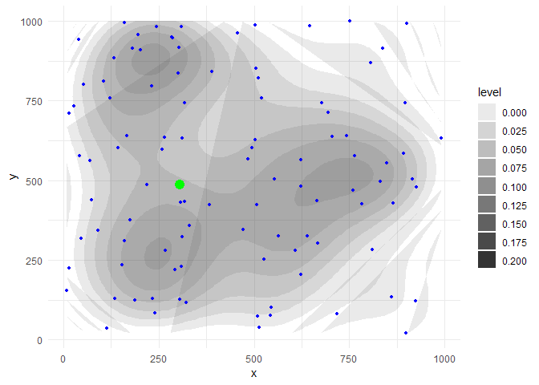

```r
ggplot(df,aes(x=x,y=y))+
  stat_density2d(aes(alpha=..level..), geom="polygon") +
  scale_alpha_continuous(limits=c(0,0.2),breaks=seq(0,0.2,by=0.025))+
  geom_point(colour="red",alpha=0.02)+
  geom_point(mapping = aes(x = 306, y = 486), col = "green", size = 4) +
  geom_point(df, mapping = aes(x = x, y = y), size = 1, col="blue") +
  theme_minimal()
```

# 4) Risoluzione del problema con la libreria optimx

```r
#Codice in cui vengono riscritte le funzioni per essere compatibili con la libreria optimx:

fun.r <- function(st){
  res <- 0
  for (i in c(1:nrow(df))) {
    res <- (log((st[1] - df$x[i])^2 + 1)) + (log((st[2] - df$y[i])^2 + 1)) + res
  }
  return(res)
}

gradient.r <- function(st){
  res1 <- 0
  res2 <- 0
  for(i in c(1:nrow(df))){
    res1 <- (2*(st[1]-df$x[i]))/((st[1]-df$x[i])^2 + 1) + res1
    res2 <- (2*(st[2]-df$y[i]))/((st[2]-df$y[i])^2 + 1) + res2
  }
  return(c(res1, res2))
}
```

```r
library(optimx)
strt = c(x,y)
rez = optimr(par = strt, fn = fun.r, gr = gradient.r,  method="CG")
proptimr(rez)
```

```
## Result  rez   proposes optimum function value = 2039.609  at parameters
## [1] 310.1627 376.0069
## After  63  fn evals, and  29  gr evals
## Termination code is  0 :
## ---------------------------------------
```

Il punto che viene suggerito come ottimo dalla libreria optimr è $s_{opt} = ($ 310.1627153, 376.0068943 $)$, il valore della funzione in questo punto risulta essere 2039.6093234.  
Dal punto di vista grafico i punti restituiti dall’algoritmo da me implementato e dall’algoritmo CG della libreria optimr sono rappresentati rispettivamente con un punto verde ed uno giallo:

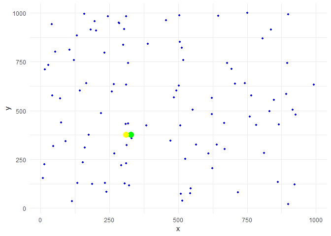

```r
plot = ggplot(df, aes(x = x, y = y)) +
  geom_point(size = 1, col= "blue") +
  geom_point(mapping = aes(x = result[1], y = result[2]), col = "green", size = 4) +
  geom_point(mapping = aes(x = rez$par[1], y = rez$par[2]), col = "yellow", size = 4) +
  theme_minimal()
plot
```

Si nota che il metodo “CG” della funzione optimr restituisce un risultato diverso, anche il numero di iterazioni eseguite è differente.

# 5) Implementazione dell’algoritmo Stochastic Gradient Descent e risoluzione del problema con esso

```r
stoch_gradDescent = function(df, start, gradient, lr, iters){

  beta = start

  betaIter = data.frame(matrix(NA, nrow = iters, ncol = 2))

  set.seed(42)

  # now iterate using mini batches of randomly sampled  data, updating theta each step
  for (i in 1:iters) {
    # randomly sample 5 items from the combined xy data frame
    df_temp = data.frame(as.matrix( df[sample(nrow(df), 15), ] ))

    beta = beta - lr  * gradient(beta[1], beta[2], df_temp)

    # save the beta values for iteration i to a matrix for future plotting
    betaIter[i,] = beta

 } # end for loop
 return(betaIter)
}
```

## Risoluzione del problema con Stochastic Gradient Descent

Si effettua la risoluzione del problema partendo dal punto della mappa $q_1 = ($ 340, 380 $)$, lo stesso utilizzato per valutare i risultati delle funzioni optimr e Deepest Descent Method:

```r
resstoc = stoch_gradDescent(df, start, gradient, 0.01, 1000)
res = data.frame(gradientDescent(df, start, gradient, 0.01, 1000))
colnames(resstoc)= c("chi", "nu")
colnames(res) = c("chi", "nu")

risultato_stocastico = resstoc[1000,]
min_fostoc = fun(risultato_stocastico[1], risultato_stocastico[2], df)
risultato_deepest = res[1001,]
min_fo = fun(risultato_deepest[1], risultato_deepest[2], df)
```

L’esecuzione del metodo produce il seguente risultato: L’ottimo viene trovato nel punto $q_{opt} = ($ 338.4076558, 379.4341557 $)$ con il valore della funzione pari a 2091.817215, a differenza del metodo Deepest Descent che restituisce il punto ottimo $p_{opt} = ($ 327.783271, 376.006984 $)$ con valore associato della funzione pari a 2073.9423219.  
Dal punto di vista grafico i due punti minimi appena restituiti dai relativi metodi sono rappresentabili come segue:

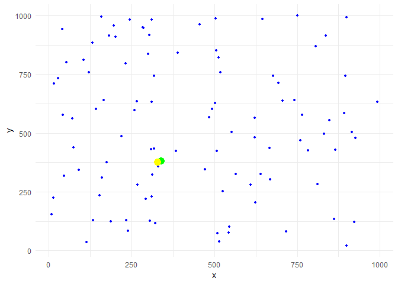

```r
plot = ggplot(df, aes(x = x, y = y)) +
  geom_point(size = 1, col= "blue") +
  geom_point(mapping = aes(x = risultato_stocastico$chi, y = risultato_stocastico$nu), col = "green", size = 4) +
  geom_point(mapping = aes(x = risultato_deepest$chi, y = risultato_deepest$nu), col = "yellow", size = 4) +
  theme_minimal()
plot
```

Il punto verde è associato al metodo *Stochastic Gradient Descent* e quello giallo associato al *Deepest Descent Method*.

## Ottimizzazione dell’algoritmo Stochastic Gradient Method

A partire dai 25 punti noti che sono stati utilizzati per ottimizzare il Deepest Descent Method si effettua l’esecuzione del Stochastic Gradient Method:

```r
results2 = data.frame(matrix(NA, ncol=2, nrow=25))
for(i in 1:25){
  temp2 = as.data.frame(stoch_gradDescent(df, coord[[i]], gradient, 0.01, iters = 1000))
  results2[i,1] = temp2$X1[1000]
  results2[i,2] = temp2$X2[1000]
}
colnames(results2) = c("X","Y")

for (i in 1:25){
  results2$FO[i] = fun(results2$X[i], results2$Y[i], df)
}
min_fo2 = min(results2$FO)
minpt2 = c(results2$X[which(results2$FO == min_fo2)],results2$Y[which(results2$FO == min_fo2)])
```

Graficamente il risultato viene così visualizzato: il pallino rosso è il punto minimo restituito dal metodo Stochastic Gradient Descent, quello verde dal metodo Deepest Descent

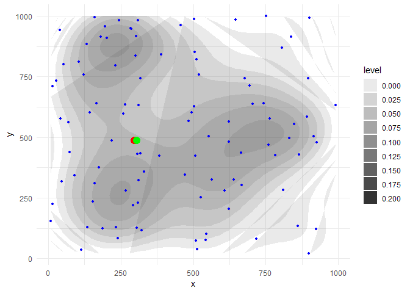

```r
ggplot(df,aes(x=x,y=y))+
  stat_density2d(aes(alpha=..level..), geom="polygon") +
  scale_alpha_continuous(limits=c(0,0.2),breaks=seq(0,0.2,by=0.025))+
  geom_point(colour="red",alpha=0.02)+
  geom_point(mapping = aes(x = 296, y = 487), col = "red", size = 4) +
  geom_point(mapping = aes(x = 306, y = 486), col = "green", size = 4) +
  geom_point(df, mapping = aes(x = x, y = y), size = 1, col="blue") +
  theme_minimal()
```

## Valutazione del metodo Stochastic Gradient Descent

### Confronto con diversi Learning Rate

Si vuole effettuare una valutazione del metodo Stochastic Gradient Descent considerando 4 diverse grandezze “lr” (Learning Rate):

- 0.001
- 0.01
- 0.1
- 1

L’applicazione di esempio viene effettuata a partire dal punto iniziale $p = (491.5, 488.5)$:

```r
R1 = as.data.frame(stoch_gradDescent(df, c(491.5, 488.5), gradient,  0.001, 1000))

R2 = as.data.frame(stoch_gradDescent(df, c(491.5, 488.5), gradient, 0.01, 1000))

R3 = as.data.frame(stoch_gradDescent(df, c(491.5, 488.5), gradient, 0.1, 1000))

R4 = as.data.frame(stoch_gradDescent(df, c(491.5, 488.5), gradient, 1.0, 1000))
```

Graficamente è possibile osservare lungo l’arco di iterazioni come si converga all’ottimo restituito:

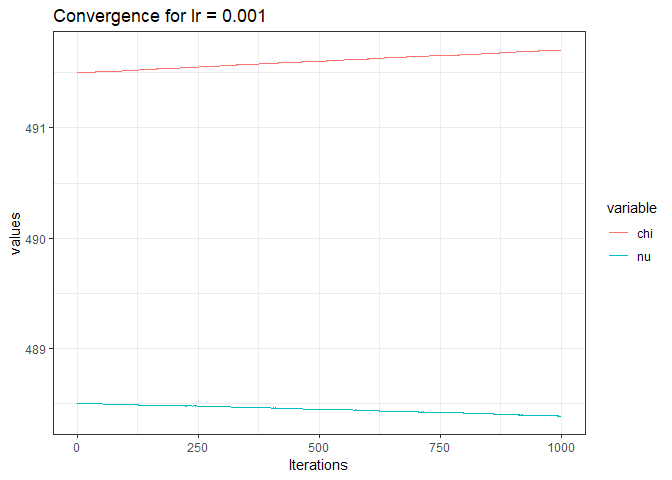

```r
arrangeAndPlot(R1, '0.001')
```

Il primo metodo, con lr pari a 0.001 si avvicina molto lentamente al punto di convergenza, alla iterazione n°1000 non ha ancora raggiunto l’ottimo.

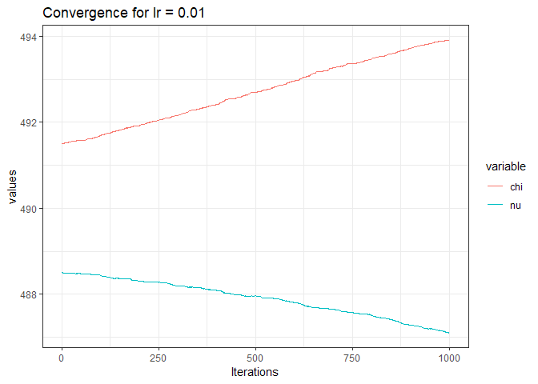

```r
arrangeAndPlot(R2, '0.01')
```

Anche nel modello con lr pari a 0.01 ci si avvicina lentamente al punto ottimo senza però raggiungerlo entro la millesima iterazione.

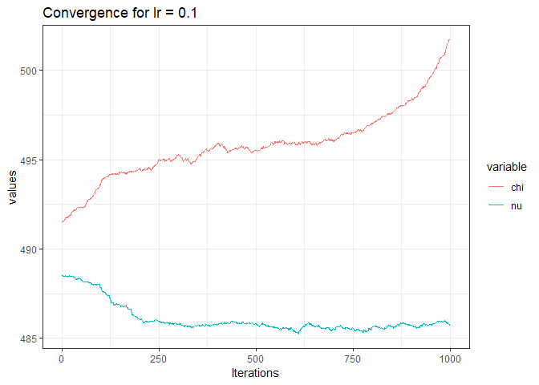

```r
arrangeAndPlot(R3, '0.1')
```

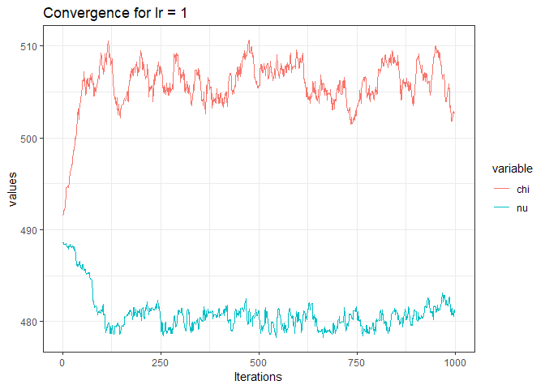

```r
arrangeAndPlot(R4, '1')
```

L’ultimo modello permette di osservare che assegnare il valore 1 a lr è esagerato, l’algoritmo si avvicina rapidamente all’ottimo per rimanere nella zona circostante, continuando a divergere attorno ad esso, senza mai raggiungerlo definitivamente.  
Si conclude affermando che la performance del metodo è strettamente legata ad una buona combinazione di parametri che vengono scelti, in particolare il valore lr ed il numero di iterazioni, oltre che dal punto da cui ha inizio l’esecuzione.